# Processing and analysis of MALDI-imaging data

John Abbey

Department for Quantitative Biomedicine, University of Zurich  
Institute for Molecular Health Sciences, ETH Zurich

john.abbey@uzh.ch

6 September 2023

#### Abstract

This R package supports the processing and analysis of highly multiplexed MALDI-imaging data. The data handling capabilities (import, pre-processing, export) build heavily on the R package Cardinal, designed for general Mass Spectrometry Imaging data. The main functionality of this package includes reliable data processing, extensive quality control and data analysis. First, data is processing using a novel approach involving the construction of metapeaks to account for mass shift and the presence of isotopic peaks. Then image-level and spatial quality control statistics, such as computing Geary’s C scores can be computed for every marker. Furthermore, spatial analysis can be performed on the high-dimensional images, including constructing variograms and a variety of clustering algorithms. The package also supports dimensionality reduction methods, including PCA, NMF and UMAP. Additionally, the package supports image visualisation from cytomapper (and cytoviewer) through the construction of a CytoImageList object. As such, once the data is coerced to this format, many of the analysis techniques that are applicable to CytoImageList can be applied.

#### Package

maldipackage 0.1.0

# 1 Introduction

## 1.1 Overview

The `maldipackage` package exports functions and example data to perform the following analyses:

1. Read in raw datadata
2. Perform data pre-processing
3. Data processing
4. Visualisation of processed targeted images
5. Dimensionality reduction of processed targeted images
6. Community detection

To highlight the usability of these function, the `maldipackage` package also exports a number of test data files.

### 1.1.1 MALDI-imaging

# 2 Read in raw data and panel

The raw imaging data can be read into R using the `readMSIData` function from Cardinal.

```r
imzML_path <- system.file("extdata/Example_data.imzML", package = "maldipackage")
rawFile <- Cardinal::readMSIData(imzML_path)
```

The `readPanel` function can be used to read a .csv file into R. containing the information for the mass of the peptide tag and the molecular target into R.

```r
panel_path <- system.file("extdata/ref_list.csv", package = "maldipackage")
panel <- maldipackage::readPanel(panel_path)
```

# 3 Example data

If you want to see how the package functions on test data, or do not have access to the required data yet, a good place to start is by loading in the example data from the github repository. The `maldipackage` package contains example data generated by the RapiFlex imaging system. The following section gives an overview of these files.

These files are accessible via:

```r
path <- system.file("extdata", package = "maldipackage")
list.files(path, recursive = TRUE)
```

```
## [1] "Example_data.ibd"   "Example_data.imzML" "ref_list.csv"
```

# 4 Data pre-processing

When acquiring the raw data, the resulting spectra can often be noisy and messy. To correct for this, some pre-processing steps are required. This can be done simply using the `preProcess` function from this package, which can be implemented as follows.

```r
pre <- preProcess(rawFile, cores = 2)
```

This function is a wrapper for the Cardinal functions `normalize`, `smoothSignal` and `reduceBaseline`, using common parameters and methods for each function. For more flexibility in your pre-processing, it is recommended to directly use the Cardinal functions. Here, we use total ion current (TIC) as the normalisation method of choice, Gaussian smoothing for spectral smoothing and local minimum baseline reduction.

```r
pre <- rawFile %>%
    Cardinal::normalize(method = "tic") %>%
    smoothSignal(method = "gaussian", plot = FALSE) %>%
    reduceBaseline(method = "locmin") %>%
    process(BPPARAM = MulticoreParam(workers = 2))
```

# 5 Data processing

Full processing of the pre-processed MALDI-imaging data can be performed using the `peakDetection`, `metapeakGeneration` and `assignMetapeaks` functions in series.

## 5.1 Peak Detection

The first step of processing is to identify peaks in the pre-processed spectra. This function is essentially a wrapper for `Cardinal::peakPick`, and uses the median adaptive deviation (MAD) peak detection algorithm for robust noise evaluation.

```r
detected <- maldipackage::peakDetection(pre, snr = 3, cores = 2)
```

## 5.2 Metapeak generation

Once `peakDetection` has been performed, the detected peaks per pixel can be used to generate metapeaks. Here, metapeaks are defined as single peaks that correspond to clusters of peaks that contain information on the same molecular species. The function used to generate these metapeaks is `metapeakGeneration`. This step is implemented to account for loss of signal through technical shift and isotopic peaks in the spectra. Inside this function, metapeaks are constructed by

1. Obtaining the number of pixels in which each detected peak is present.
2. Gaussian smoothing over the spectrum
3. Watershed algorithm to cluster detected peaks
4. Filter peaks present in less than a given threshold of pixels, which can be controlled using the `threshold` parameter.

It is important to note that metapeaks are not restricted to targeted peaks. Many of the metapeaks generated will be formed by signal that is from untargeted peaks.

```r
metapeaks <- maldipackage::metapeakGeneration(detected)
```

## 5.3 Assigning metapeaks

The final step of processing is to assign metapeaks to the reference list of masses that was loaded in using the `readPanel` function. This is performed using the `assignMetapeaks` function. The output of this function is a list of lists, containing primarily `IntensityDF`, the channel-specific intensities, `SpatialCoords`, the spatial coordinates and `CorrespondenceMatrix`, a data frame describing the assignment of metapeaks to reference peaks. This assignment can be controlled via the `mz_threshold` parameter, which has a default of 1m/z.

You may notice that some of the expected peaks in the reference list will not appear in the output. This is likely due to either a lack of signal, resulting in the metapeak not passing the filter threshold during `metapeakGeneration`, or the metapeak center being out of range for assignment to a reference peak during `assignMetapeaks`. These parameters can be adjusted to improve results.

```r
processed <- maldipackage::assignMetapeaks(metapeaks, refList = panel, pre = pre)
```

# 6 Visualisation of processed data

## 6.1 Cytomapper

```r
library(cytomapper)
cil <- asCytoImageList(processed)
```

Now the channels can be visualised using the `plotPixels` function. Single channel and multichannel imaging is supported using this format.

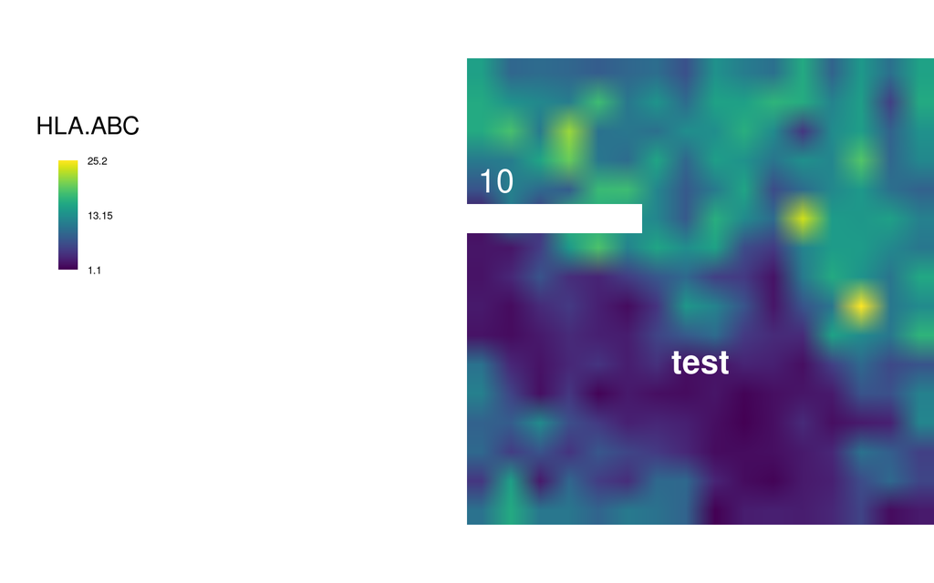

```r
cytomapper::plotPixels(image = cil, colour_by = "HLA.ABC")
```

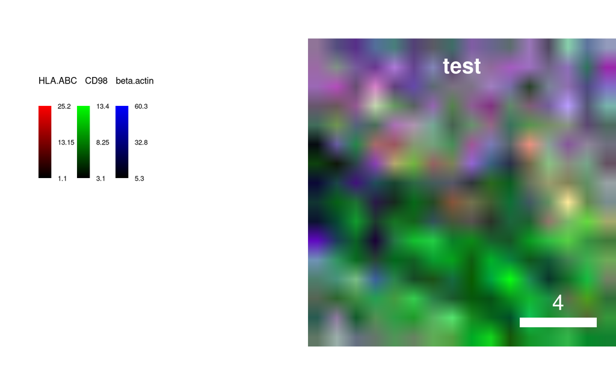

```r
plotPixels(cil, colour_by = c("HLA.ABC", "CD98", "beta.actin"),
           legend = list(colour_by.title.cex = 0.7),
           scale_bar = list(length = 4, lwidth = 0.5, margin = c(1,1)),
           image_title = list(margin = c(1, 1)))
```

## 6.2 Cytoviewer

```r
library(cytoviewer)
cytoviewer(cil)
```

Shiny applications not supported in static R Markdown documents

# 7 Dimensionality Reduction

## 7.1 Principal Component Analysis (PCA)

Dimensionality reduction techniques can be helpful in revealing the overall structure of the data, especially during the exploratory phase of data analysis. This package explicitly supports PCA, NMF and UMAP.

PCA is a very commonly used techniques which linearly separates the data according to the orthogonal dimensions with greatest variance. This can be performed using the `pca` function. This function wraps the `irlba` implementation of PCA, requiring a set seed. This takes the targeted intensity dataframe as the main argument. The number of components, aswell as some plotting functions can also be chosen as arguments.

Once this is performed, the loadings for each component can be accessed under `my_pca$rotation`.

```r
my_pca <- maldipackage::pca(processed$IntensityDF, comp = 5, scree = TRUE)
```

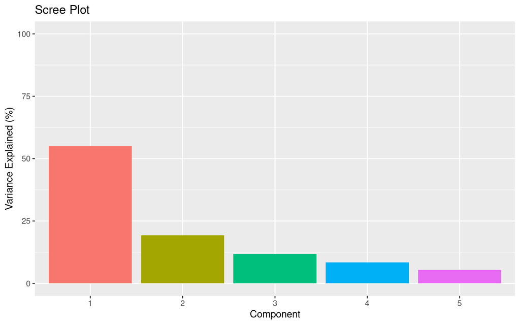

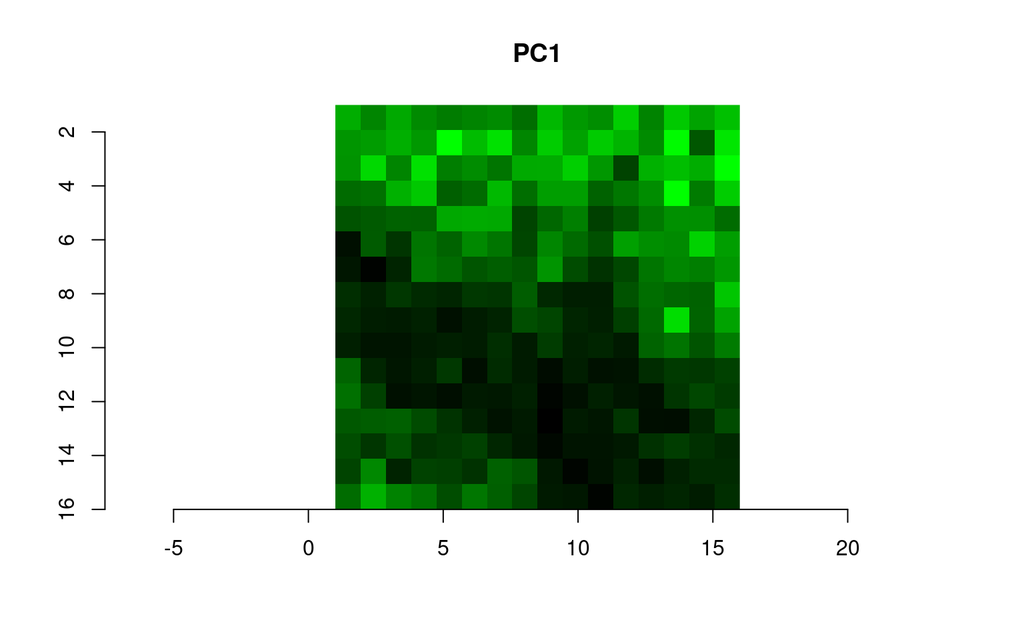

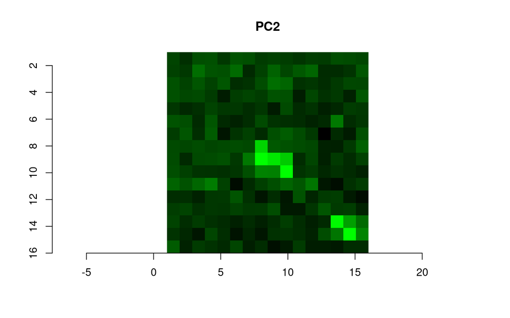

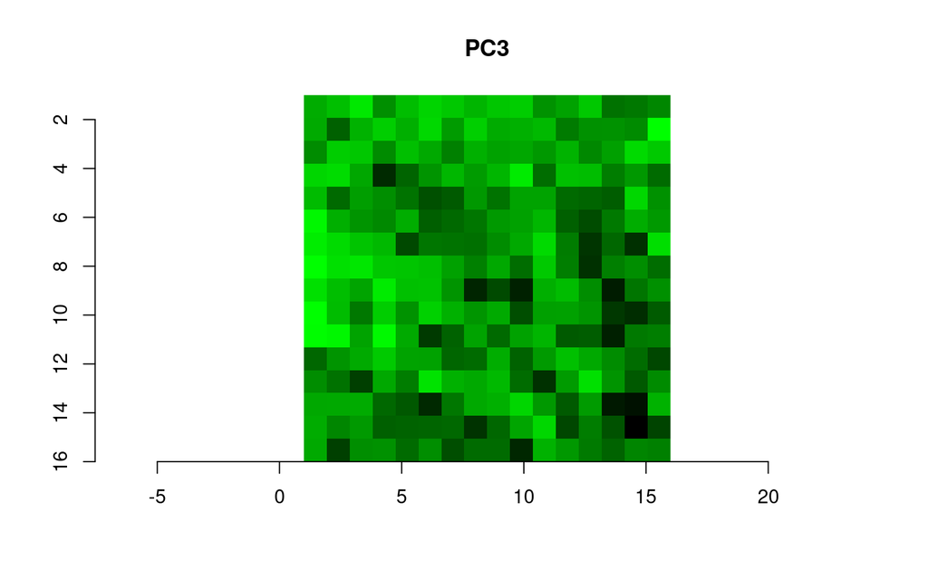

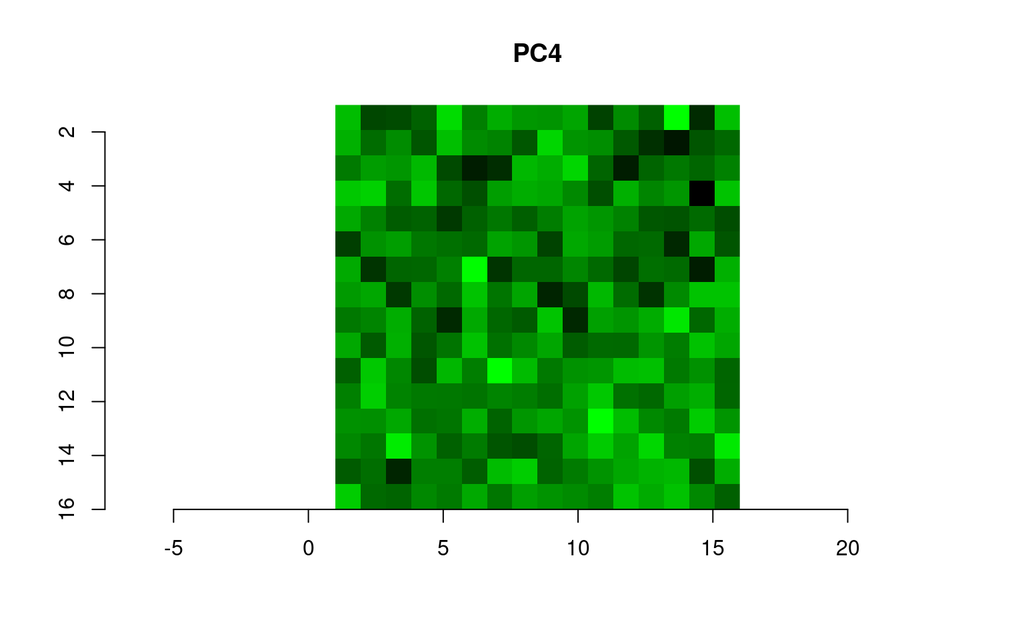

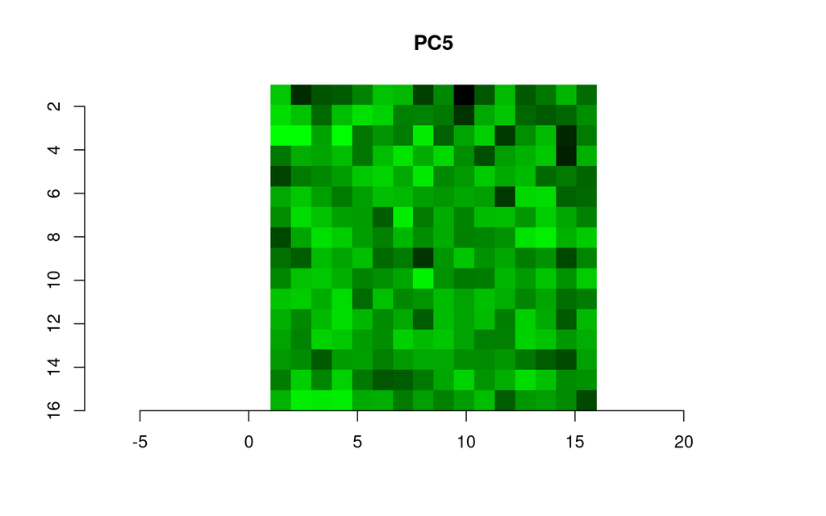

```r
for (i in 1:ncol(my_pca$x)){
  maldipackage::imageChannel(my_pca$x, coords = processed$SpatialCoords, channel_number = i)
}
```

## 7.2 Non-negative Matrix Factorisation (NMF)

```r
my_nmf <- maldipackage::nmf(processed$IntensityDF, comp = 5)
```

```
##
## iter |      tol
## ---------------
##    1 | 8.98e-01
##    2 | 7.60e-02
##    3 | 1.29e-02
##    4 | 4.05e-03
##    5 | 2.61e-03
##    6 | 2.65e-03
##    7 | 2.43e-03
##    8 | 1.67e-03
##    9 | 9.81e-04
##   10 | 4.19e-04
##   11 | 2.23e-04
##   12 | 1.71e-04
##   13 | 1.38e-04
##   14 | 1.16e-04
##   15 | 1.01e-04
##   16 | 8.92e-05
```

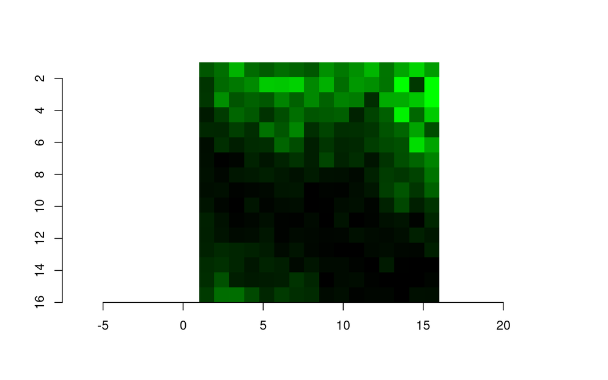

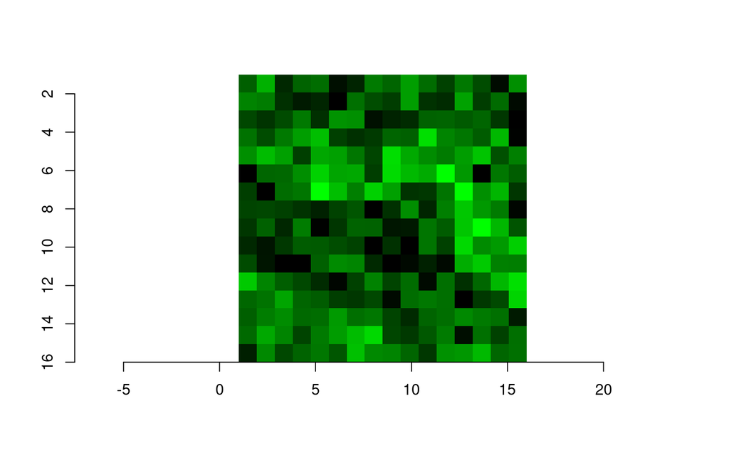

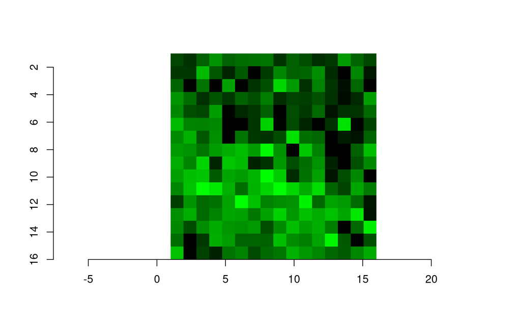

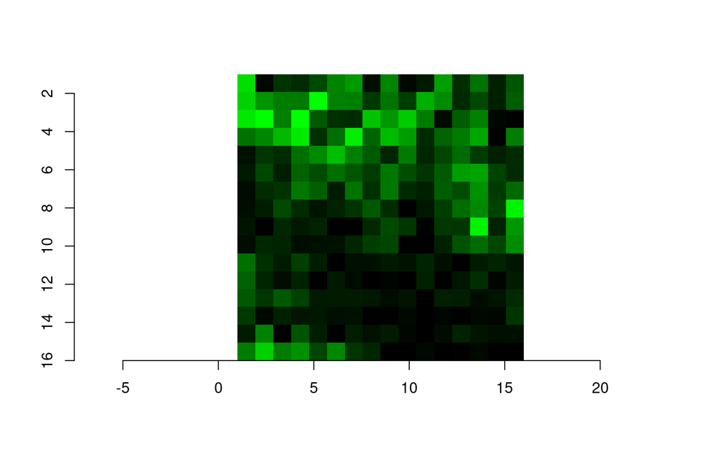

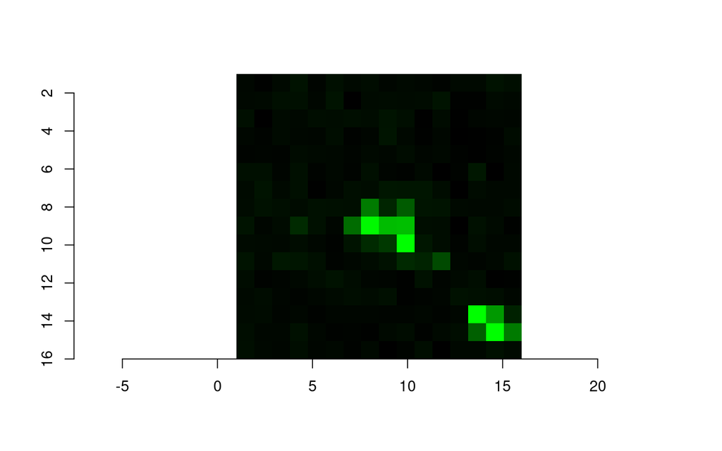

```r
# visualise the factored dimensions
for (i in 1:ncol(my_pca$x)){
  maldipackage::imageChannel(my_nmf$w, coords = processed$SpatialCoords, channel_number = i)
}
```

## 7.3 Uniform Manifold Approximate Projection (UMAP)

UMAP is a non-linear dimensionality technique that embeds high dimensional data into two dimensions, providing an overview of the global structure of the data.

This package includes the `computeUMAP` function, which computes the UMAP using the `uwot` package implementation.

```r
my_umap <-computeUMAP(processed$IntensityDF)
```

One of the ways in which UMAP can be used is to display single-channel intensity information on top of the UMAP.

[figure not shown]

```r
# create data frame
umap_df <- cbind(my_umap, processed$IntensityDF)

# plot UMAP with channel intensity
library(ggplot2)
ggplot(umap_df) +
  geom_point(aes(x = UMAP1, y = UMAP2, color = HLA.ABC), alpha = 0.6, size = 1) +
  scale_color_viridis_c() +
  theme_minimal() +
  theme(legend.position = "right") +
  labs(title = "HLA.DR",
       x = "UMAP 1",
       y = "UMAP 2",
       color = "Intensity")
```